# AFLIBER - Create New Version (AFLIBER2.0)

2025-10-13

## 1. Regeneración de la lista de especies

```r
source(here::here("R/AFLIBER_1. Species list regeneration.R"))
readr::write_csv(AFLIBER_specieslist_new, "AFLIBER_v2.0.0/AFLIBER_v2_Species_list.csv" )

print(AFLIBER_specieslist_new[!(AFLIBER_specieslist_new$Taxon %in% AFLIBER_specieslist_old$Taxon),])
```

```
## # A tibble: 21 × 11
##    Taxon     Scientific_Name Endemic Genus Species Subspecies Class Order Family
##    <chr>     <chr>           <lgl>   <chr> <chr>   <chr>      <chr> <chr> <chr>
##  1 Carex ca… "Carex camposi… TRUE    Carex campos… tejedensis Magn… Poal… Cyper…
##  2 Castrila… "Castrila late… TRUE    Cast… latens  <NA>       Magn… Gent… Rubia…
##  3 Cathissa… "Cathissa vill… TRUE    Cath… villas… <NA>       Magn… Aspa… Aspar…
##  4 Digitari… "Digitaria deb… FALSE   Digi… debilis <NA>       Magn… Poal… Poace…
##  5 Euphorbi… "Euphorbia gua… TRUE    Euph… guadal… <NA>       Magn… Malp… Eupho…
##  6 Festuca … "Festuca panic… FALSE   Fest… panicu… longiglum… Magn… Poal… Poace…
##  7 Galatell… "Galatella mal… TRUE    Gala… malaci… <NA>       Magn… Aste… Aster…
##  8 Galium p… "Galium pierre… TRUE    Gali… pierre… <NA>       Magn… Gent… Rubia…
##  9 Genista … "Genista hirsu… FALSE   Geni… hirsuta silicicola Magn… Faba… Fabac…
## 10 Isoetes … "Isoetes lacus… FALSE   Isoe… lacust… <NA>       Lyco… Isoe… Isoet…
## # ℹ 11 more rows
## # ℹ 2 more variables: GBIF_id <chr>, POW_Name <chr>
```

## 2. Recopilación de citas nuevas

Se incluyen todos los datasets que hayan sido incluidos como ramas nuevas en el repositorio de GitHub (cada rama tiene un citationkey identificador del dataset).

Se crea un dataset nuevo (`AFLIBER_novelties`), además de cargar los datos antiguos (`AFLIBER_distributions_old`)

```r
source(here("R/AFLIBER_2. merge_novelties.R"))

print(as_tibble(AFLIBER_novelties))
```

```
## # A tibble: 515,493 × 5
##    Taxon                          UTM10x10 UTM1x1 References              branch
##    <chr>                          <chr>    <chr>  <chr>                   <chr>
##  1 Adonis annua                   30TYK13  <NA>   Pérez Dacosta, J.M. 20… ABM_M…
##  2 Astragalus hamosus             30TYK23  <NA>   Pérez Dacosta, J.M. 20… ABM_M…
##  3 Cytinus ruber                  30TYK23  <NA>   Pérez Dacosta, J.M. 20… ABM_M…
##  4 Cytinus ruber                  30TYK13  <NA>   Pérez Dacosta, J.M. 20… ABM_M…
##  5 Erodium neuradifolium          30TYK03  <NA>   Pérez Dacosta, J.M. 20… ABM_M…
##  6 Jasione mansanetiana           30TYK23  <NA>   Pérez Dacosta, J.M. 20… ABM_M…
##  7 Jasione mansanetiana           30TYK13  <NA>   Pérez Dacosta, J.M. 20… ABM_M…
##  8 Lathyrus saxatilis             30TYK23  <NA>   Pérez Dacosta, J.M. 20… ABM_M…
##  9 Lathyrus saxatilis             30TYK24  <NA>   Pérez Dacosta, J.M. 20… ABM_M…
## 10 Linaria depauperata ilergabona 30TYK24  <NA>   Pérez Dacosta, J.M. 20… ABM_M…
## # ℹ 515,483 more rows
```

## 3. Referencias numéricas

Los nuevos datos tienen referencias bibliográficas incorporadas como texto que tienen que incluirse en la tabla de referencias numéricas. Además, hay que hacer algunas modificaciones individuales por asignaciones de referencias no existentes (muchas veces a causa de “arrastrar” en excel, generando *doi*s de números consecutivos).

```r
source(here::here("R/AFLIBER_3. Reference numbers.R"))
```

```
##
##  Plant-plant interactions and local patte...  |  40 rows changed
##  Nuevos datos sobre las orquídeas silvest...  |  11 rows changed
##  Additions to the smut fungi of the Iberi...  |  21 rows changed
##  Synanthropisation of coastal vegetation ...  |  89 rows changed
##  FAME (2002)                                  |  1 rows changed
##  FAME (2004)                                  |  1 rows changed
##  FAME (2005)                                  |  1 rows changed
##  FAME (2006)                                  |  1 rows changed
##  FAME (2007)                                  |  1 rows changed
##  FAME (2009)                                  |  1 rows changed
##  FAME (2010)                                  |  1 rows changed
##  FAME (2011)                                  |  1 rows changed
##  FAME (2012)                                  |  1 rows changed
##  FAME (2013)                                  |  1 rows changed
##  FAME (2015)                                  |  1 rows changed
##  FAME (2016)                                  |  1 rows changed
##  FAME (2021)                                  |  1 rows changed
##  FAME (2022)                                  |  1 rows changed
##  nuevo endemismo para el sistemaibérico m...  |  19 rows changed
##  conocimiento de la pteridoflora              |  116 rows changed
##  Nuevas aportaciones al conocimiento de l...  |  63 rows changed
##  Martín Gil, T.  (2021). Nuevas aportacio...  |  28 rows changed
##  Martínez-Veiga, E. & Buján-Rodríguez, I....  |  18 rows changed
##  Mateo, G., & Figuerola, J. I. P. (2021)....  |  1 rows changed
##  Mateo-Sanz, G., & Peris-Figuerola, J. I....  |  22 rows changed
##  Oltra Benavent, J. E., & Crespo Villalba...  |  33 rows changed
##  Romero Bujan, M. I. (2022). Notas sobre ...  |  17 rows changed
##  Nuevos datos florísticos, correcciones y...  |  29 rows changed
##  Silva, V., Pina, A. R., Oliveira, H., Pa...  |  2 rows changed
##  Silva, V., Ribeiro, S., Molina J.A., Pin...  |  18 rows changed
##  Vázquez Pardo, F. M., González-Muñoz, A....  |  35 rows changed
##  Villar J.L., Alonso M.Á., Crespo M.B. 20...  |  191 rows changed
##  Barredo, J. J., & Barredo U. (2002). Apr...  |  2 rows changed
##  Casimiro-Soriguer Solanas, F., Pérez Lao...  |  4 rows changed
##  Sanna, M., Cires, E. & Fernández-Prieto,...  |  22 rows changed
##  Aizpuru, I. Aperribay, J. A., Aseginolaz...  |  2 rows changed
##  Baladrón González, J., Pino Pérez, J. J....  |  2 rows changed
##  Barredo, J. J. (2001) Aportacciones coro...  |  2 rows changed
##  Barredo, J. J., & Barredo U. (2002). Apr...  |  4 rows changed
```

[output cut: 32 more lines]

```
##  P00549874 (1890)                             |  1 rows changed
##  SEV 55030 (1980)                             |  1 rows changed
##  SEV 79639                                    |  1 rows changed
##  SEV90412 (1980)                              |  1 rows changed
##  Tercero-Araque et al. (2023)                 |  1 rows changed
##  Tercero-Araque et al. (2023), ABH 74138      |  1 rows changed
##  Tercero-Araque et al. (2023); GDA 21234 ...  |  1 rows changed
##  Aparicio & Silvestre (1987)                  |  1 rows changed
##  Aparicio & Silvestre (1987), FAME (2006)...  |  1 rows changed
##  FAME (2011), Aparicio & Silvestre (1987)...  |  1 rows changed
##  Aparicio & Silvestre (1987), Martínez Az...  |  1 rows changed
##  Barredo, J. J., & Barredo, U. Distribuci...  |  1 rows changed
##  Casimiro-Soriguer Solanas et al. (2019)      |  1 rows changed
##  Díez & Pastor (1985)                         |  1 rows changed
##  FloraOn                                      |  1 rows changed
```

```r
new_sources |>
  arrange(desc(`NUMBER OF OCCURRENCES`)) |>
  as_tibble() |>
  print()
```

```
## # A tibble: 371 × 4
##    `NUMERIC REFERENCE` REFERENCE                 CITATION NUMBER OF OCCURRENCE…¹
##                  <dbl> <chr>                     <chr>                     <int>
##  1                 398 Mateo, G. (2024). Person… Mateo, …                 262675
##  2                 272 Flora-On: Flora de Portu… Flora-O…                  75579
##  3                 208 Buira, A., Fernández-Maz… Buira, …                  39751
##  4                 274 Folia Botanica Extremadu… Folia B…                  22858
##  5                 501 Serra Laliga, L. 2019. L… Serra L…                  18339
##  6                 502 Serra Laliga, L. 2021. E… Serra L…                  17169
##  7                 485 Salazar Mendías, C (2024… Salazar…                   9999
##  8                 432 Peralta de Andrés J. 202… Peralta…                   8378
##  9                 273 FlorAnd: Flora de Andalu… FlorAnd…                   6494
## 10                 442 Picornell-Segura, Eulàli… Picorne…                   4152
## # ℹ 361 more rows
## # ℹ abbreviated name: ¹`NUMBER OF OCCURRENCES`
```

```r
bind_rows(old_sources, new_sources) |>
  arrange(`NUMERIC REFERENCE`) |>
  rename(Numeric_reference = `NUMERIC REFERENCE`,
         Reference = `REFERENCE`,
         Citation = `CITATION`,
         Number_occurrences = `NUMBER OF OCCURRENCES`) |>
  write_csv(file = "AFLIBER_v2.0.0/AFLIBER_v2_DataSources.csv")
```

## 4. Eliminación de errores

Por último, hay que eliminar todos los errores que se han ido detectando en los distintos procesos de limpieza del dataset. Para evitar incluir errores que ya se detectaron en procesos previos, se combinan todos los datasets de corrección y luego se eliminan los registros.

Esto potencialmente puede conducir a la eliminación sistemática de una cita al estar en una cuadrícula descartada. En este caso, habría que eliminar esa corrección, pero al ser un criterio experto que tiene que estar convenientemente contrastado, lo mejor es hacerlo de este modo.

```r
source("R/AFLIBER_4. Occurrence corrections.R")
```

```
## 4648 rows removed
```

```r
print(AFLIBER_distributions_final)
```

```
## # A tibble: 1,942,750 × 3
##    Taxon      UTM10x10 References
##    <chr>      <chr>    <chr>
##  1 Abies alba 30TXM89  999
##  2 Abies alba 30TXM99  999
##  3 Abies alba 30TXN27  6
##  4 Abies alba 30TXN32  999
##  5 Abies alba 30TXN33  999
##  6 Abies alba 30TXN34  114_999
##  7 Abies alba 30TXN35  114
##  8 Abies alba 30TXN36  6_12_114_999
##  9 Abies alba 30TXN38  6
## 10 Abies alba 30TXN44  6_83_114_999
## # ℹ 1,942,740 more rows
```

```r
readr::write_csv(AFLIBER_distributions_final, "AFLIBER_v2.0.0/AFLIBER_v2_Distributions.csv" )
```

## 5. Resumen de los datos incorporados

Podemos visualizar los mapas de riqueza de la primera y segunda versión; además de ver la distribución de datos de las novedades.

```r
source("R/AFLIBER_5. Summary.R")
```

```
## terra 1.8.80
```

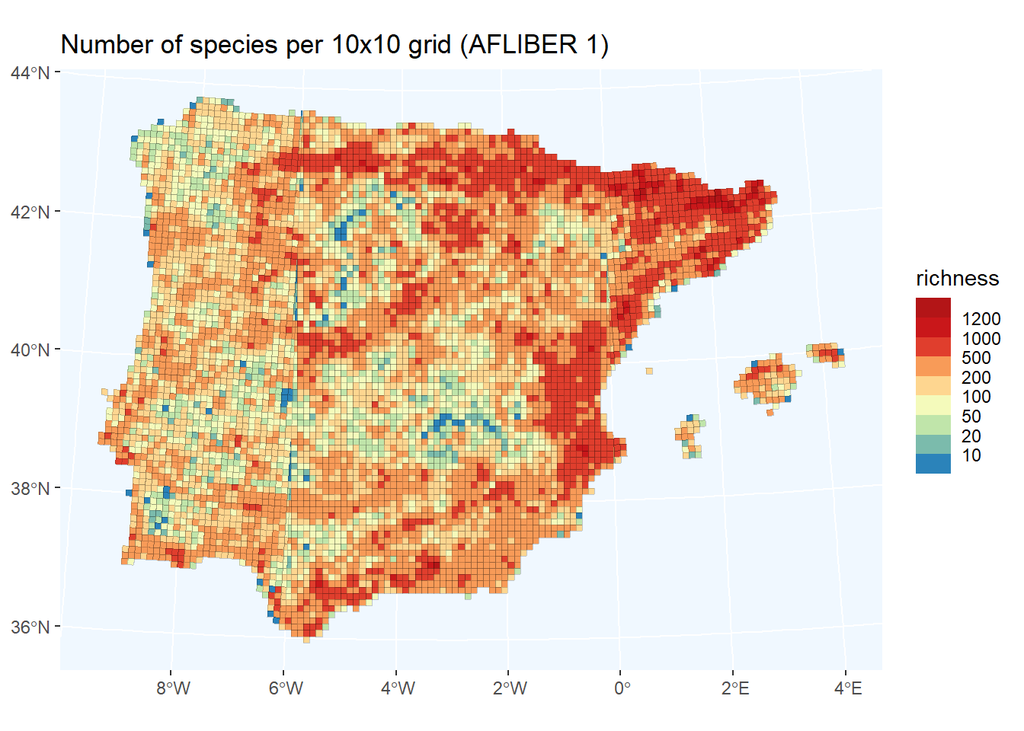

```r
old
```

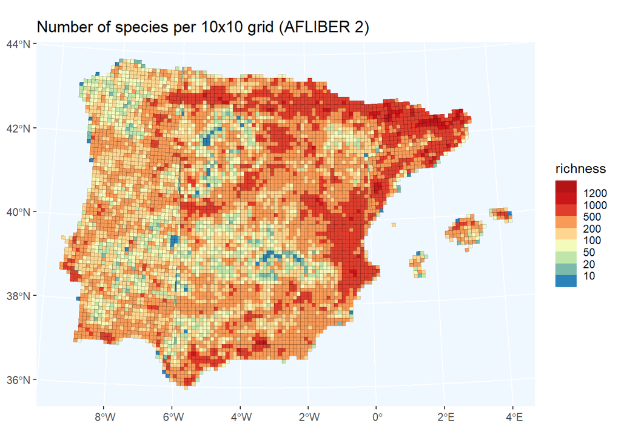

```r
new
```

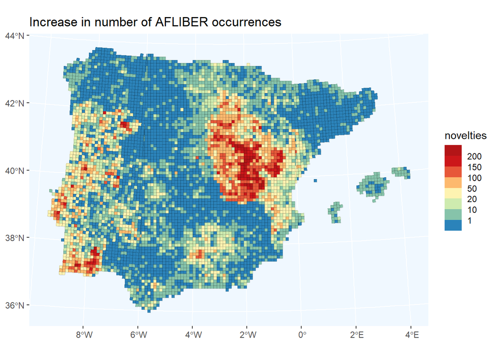

```r
diff
```

## 6. Crear mapas individuales

Generar mapas individuales para re-comprobaciones